# 5_MLPS_R_logistic_nonlinear_regression

Zhe Zhang (TA - Heinz CMU PhD)

1/24/2017

## Lecture 5: Logistic Regression & Beyond Linearity

Key specific tasks we covered in this lecture:

- logistic regression
- interaction effects and transformed variables in linear models
- basis functions, natural cubic spline, regression splines and knots
- standard error curves for linear regression fits
- local regression
- Generalized Additive Models (GAMs)

In this cheatsheet, we’ll focus on the base R functions for these actions. The `caret` package should have alternative implementations for several of these that build upon these base functions.

Logistic regression (see more here http://www.ats.ucla.edu/stat/r/dae/logit.htm).

```r
## Logistic Regression
#   we need to run a generalized linear model (GLM)
#   a simple/multiple linear model is simply a GLM with
#     an identity link function and a Gaussian family of error variance
#   a logit model has a binomial error variance, with a "logit" link function
admit_data <- read.csv("http://www.ats.ucla.edu/stat/data/binary.csv")

logit_admit <- glm(admit ~ gre + gpa, data = admit_data,
                   family = binomial(link = 'logit'))
summary(logit_admit)
```

```
##
## Call:
## glm(formula = admit ~ gre + gpa, family = binomial(link = "logit"),
##     data = admit_data)
##
## Deviance Residuals:
##     Min       1Q   Median       3Q      Max
## -1.2730  -0.8988  -0.7206   1.3013   2.0620
##
## Coefficients:
##              Estimate Std. Error z value Pr(>|z|)
## (Intercept) -4.949378   1.075093  -4.604 4.15e-06 ***
## gre          0.002691   0.001057   2.544   0.0109 *
## gpa          0.754687   0.319586   2.361   0.0182 *
## ---
## Signif. codes:  0 '***' 0.001 '**' 0.01 '*' 0.05 '.' 0.1 ' ' 1
##
## (Dispersion parameter for binomial family taken to be 1)
##
##     Null deviance: 499.98  on 399  degrees of freedom
## Residual deviance: 480.34  on 397  degrees of freedom
## AIC: 486.34
##
## Number of Fisher Scoring iterations: 4
```

```r
# interaction effects using `:`
logit_interact <- glm(admit ~ gre + gpa:as.factor(rank), data = admit_data,
                   family = binomial(link = 'logit'))
summary(logit_interact)
```

```
##
## Call:
## glm(formula = admit ~ gre + gpa:as.factor(rank), family = binomial(link = "logit"),
##     data = admit_data)
##
## Deviance Residuals:
##     Min       1Q   Median       3Q      Max
## -1.6847  -0.8589  -0.6402   1.1407   2.0588
##
## Coefficients:
##                       Estimate Std. Error z value Pr(>|z|)
## (Intercept)          -4.808700   1.110835  -4.329  1.5e-05 ***
## gre                   0.002278   0.001095   2.081  0.03741 *
## gpa:as.factor(rank)1  1.039857   0.338872   3.069  0.00215 **
## gpa:as.factor(rank)2  0.842581   0.337509   2.496  0.01254 *
## gpa:as.factor(rank)3  0.652536   0.329013   1.983  0.04733 *
## gpa:as.factor(rank)4  0.590106   0.347869   1.696  0.08982 .
## ---
## Signif. codes:  0 '***' 0.001 '**' 0.01 '*' 0.05 '.' 0.1 ' ' 1
##
## (Dispersion parameter for binomial family taken to be 1)
##
##     Null deviance: 499.98  on 399  degrees of freedom
## Residual deviance: 458.44  on 394  degrees of freedom
## AIC: 470.44
##
## Number of Fisher Scoring iterations: 4
```

```r
# use the `*` to include both individual effects and interactions
logit_both <- glm(admit ~ gre + gpa*as.factor(rank), data = admit_data,
                   family = binomial(link = 'logit'))
summary(logit_both)
```

```
##
## Call:
## glm(formula = admit ~ gre + gpa * as.factor(rank), family = binomial(link = "logit"),
##     data = admit_data)
##
## Deviance Residuals:
##     Min       1Q   Median       3Q      Max
## -1.6962  -0.8668  -0.6447   1.1569   2.1014
##
## Coefficients:
##                       Estimate Std. Error z value Pr(>|z|)
## (Intercept)          -4.985768   2.480668  -2.010   0.0444 *
## gre                   0.002287   0.001102   2.075   0.0380 *
## gpa                   1.089088   0.726130   1.500   0.1337
## as.factor(rank)2      0.503294   2.961800   0.170   0.8651
## as.factor(rank)3      0.450796   3.243486   0.139   0.8895
## as.factor(rank)4     -1.508472   4.172185  -0.362   0.7177
## gpa:as.factor(rank)2 -0.342951   0.858440  -0.400   0.6895
## gpa:as.factor(rank)3 -0.515245   0.929281  -0.554   0.5793
## gpa:as.factor(rank)4 -0.009246   1.212095  -0.008   0.9939
## ---
## Signif. codes:  0 '***' 0.001 '**' 0.01 '*' 0.05 '.' 0.1 ' ' 1
##
## (Dispersion parameter for binomial family taken to be 1)
##
##     Null deviance: 499.98  on 399  degrees of freedom
## Residual deviance: 458.11  on 391  degrees of freedom
## AIC: 476.11
##
## Number of Fisher Scoring iterations: 4
```

```r
##
```

Basis Functions and Splines:

```r
library(splines)

## Basis Functions
#   in this case, the df option specifies the unique regions to fit
#   and subsequently, the number of knots too
summary(basis_reg <- lm(weight ~ bs(height, df = 5), data = women))
```

```
##
## Call:
## lm(formula = weight ~ bs(height, df = 5), data = women)
##
## Residuals:
##      Min       1Q   Median       3Q      Max
## -0.31764 -0.13441  0.03922  0.11096  0.35086
##
## Coefficients:
##                     Estimate Std. Error t value Pr(>|t|)
## (Intercept)         114.8799     0.2167 530.146  < 2e-16 ***
## bs(height, df = 5)1   3.4657     0.4595   7.543 3.53e-05 ***
## bs(height, df = 5)2  13.0300     0.3965  32.860 1.10e-10 ***
## bs(height, df = 5)3  27.6161     0.4571  60.415 4.70e-13 ***
## bs(height, df = 5)4  40.8481     0.3866 105.669 3.09e-15 ***
## bs(height, df = 5)5  49.1296     0.3090 158.979  < 2e-16 ***
## ---
## Signif. codes:  0 '***' 0.001 '**' 0.01 '*' 0.05 '.' 0.1 ' ' 1
##
## Residual standard error: 0.2276 on 9 degrees of freedom
## Multiple R-squared:  0.9999, Adjusted R-squared:  0.9998
## F-statistic: 1.298e+04 on 5 and 9 DF,  p-value: < 2.2e-16
```

```r
# Polynomial Regression
#   use poly for getting orthogonal polynomials (avoid collinearity)
logit_poly <- glm(admit ~ poly(gre, 2) + poly(gpa, 2),
                  data = admit_data,
                  family = binomial(link = 'logit'))
summary(logit_poly)
```

```
##
## Call:
## glm(formula = admit ~ poly(gre, 2) + poly(gpa, 2), family = binomial(link = "logit"),
##     data = admit_data)
##
## Deviance Residuals:
##     Min       1Q   Median       3Q      Max
## -1.2669  -0.8956  -0.7191   1.2970   2.1280
##
## Coefficients:
##               Estimate Std. Error z value Pr(>|z|)
## (Intercept)    -0.8109     0.1124  -7.215  5.4e-13 ***
## poly(gre, 2)1   6.4112     2.5419   2.522   0.0117 *
## poly(gre, 2)2  -0.9427     2.4678  -0.382   0.7025
## poly(gpa, 2)1   5.5257     2.4296   2.274   0.0229 *
## poly(gpa, 2)2   1.0189     2.3183   0.439   0.6603
## ---
## Signif. codes:  0 '***' 0.001 '**' 0.01 '*' 0.05 '.' 0.1 ' ' 1
##
## (Dispersion parameter for binomial family taken to be 1)
##
##     Null deviance: 499.98  on 399  degrees of freedom
## Residual deviance: 480.03  on 395  degrees of freedom
## AIC: 490.03
##
## Number of Fisher Scoring iterations: 4
```

```r
# Natural Splines
#   similarly, you can specify the number of knots or df
summary(nat_basis_reg <- lm(weight ~ bs(height, df = 3), data = women))
```

```
##
## Call:
## lm(formula = weight ~ bs(height, df = 3), data = women)
##
## Residuals:
##      Min       1Q   Median       3Q      Max
## -0.40677 -0.17391  0.03091  0.12051  0.42191
##
## Coefficients:
##                     Estimate Std. Error t value Pr(>|t|)
## (Intercept)         114.6386     0.2119  540.96  < 2e-16 ***
## bs(height, df = 3)1  12.9276     0.6338   20.40 4.33e-10 ***
## bs(height, df = 3)2  25.4475     0.4506   56.47 6.62e-15 ***
## bs(height, df = 3)3  49.2288     0.3198  153.92  < 2e-16 ***
## ---
## Signif. codes:  0 '***' 0.001 '**' 0.01 '*' 0.05 '.' 0.1 ' ' 1
##
## Residual standard error: 0.2583 on 11 degrees of freedom
## Multiple R-squared:  0.9998, Adjusted R-squared:  0.9997
## F-statistic: 1.679e+04 on 3 and 11 DF,  p-value: < 2.2e-16
```

Standard Error Curves for Regressions. See [this](http://stats.stackexchange.com/questions/85560/shape-of-confidence-interval-for-predicted-values-in-linear-regression) for a good explanation between the natural variance of the regression curve and the uncertainty we have about our estimation. It’s important to take both into account, and distance from the mean of our features will increase the uncertainty of our estimates. As far as I know, there’s no easy built-in way to estimate the 95% of our regression line estimate.

```r
# getting the covariance matrix of a regression's estimated coefficients
summary_lm_admit <- summary(lm(admit ~ gre + gpa, data = admit_data))
summary_lm_admit$cov.unscaled
```

```
##               (Intercept)           gre           gpa
## (Intercept)  2.095052e-01 -4.237551e-05 -5.371873e-02
## gre         -4.237551e-05  2.203566e-07 -2.570225e-05
## gpa         -5.371873e-02 -2.570225e-05  2.030265e-02
```

```r
# getting the estimated "natural" variance of the regression
natural_variance <- summary_lm_admit$sigma^2
```

Local (kernel) regressions.

```r
# LOESS
#   local polynomial regression fitting
#   (copied from the help file)
cars.lo <- loess(dist ~ speed, cars, degree = 2, se = TRUE)
predict(cars.lo, data.frame(speed = seq(5, 30, 1)), se = TRUE)
```

```
## $fit
##         1         2         3         4         5         6         7
##  7.797353 10.002308 12.499786 15.281082 18.446568 21.865315 25.517015
##         8         9        10        11        12        13        14
## 29.350386 33.230660 37.167935 41.205226 45.055736 48.355889 49.824812
##        15        16        17        18        19        20        21
## 51.986702 56.461318 61.959729 68.569313 76.316068 85.212121 95.324047
##        22        23        24        25        26
##        NA        NA        NA        NA        NA
##
## $se.fit
##        1        2        3        4        5        6        7        8
## 7.568120 5.945831 4.990827 4.545284 4.308639 4.115049 3.789542 3.716231
##        9       10       11       12       13       14       15       16
## 3.776947 4.091747 4.709568 4.245427 4.035929 3.753410 4.004705 4.043190
##       17       18       19       20       21       22       23       24
## 4.026105 4.074664 4.570818 5.954217 8.302014       NA       NA       NA
##       25       26
##       NA       NA
##
## $residual.scale
## [1] 15.29496
##
## $df
## [1] 44.6179
```

```r
# Kernel Smoothing
#   see KernSmooth for additional features
head(ksmooth(cars$speed, cars$dist, "normal", bandwidth = 2))
```

```
## $x
##   [1]  4.000000  4.212121  4.424242  4.636364  4.848485  5.060606  5.272727
##   [8]  5.484848  5.696970  5.909091  6.121212  6.333333  6.545455  6.757576
##  [15]  6.969697  7.181818  7.393939  7.606061  7.818182  8.030303  8.242424
##  [22]  8.454545  8.666667  8.878788  9.090909  9.303030  9.515152  9.727273
##  [29]  9.939394 10.151515 10.363636 10.575758 10.787879 11.000000 11.212121
##  [36] 11.424242 11.636364 11.848485 12.060606 12.272727 12.484848 12.696970
##  [43] 12.909091 13.121212 13.333333 13.545455 13.757576 13.969697 14.181818
##  [50] 14.393939 14.606061 14.818182 15.030303 15.242424 15.454545 15.666667
##  [57] 15.878788 16.090909 16.303030 16.515152 16.727273 16.939394 17.151515
##  [64] 17.363636 17.575758 17.787879 18.000000 18.212121 18.424242 18.636364
##  [71] 18.848485 19.060606 19.272727 19.484848 19.696970 19.909091 20.121212
##  [78] 20.333333 20.545455 20.757576 20.969697 21.181818 21.393939 21.606061
##  [85] 21.818182 22.030303 22.242424 22.454545 22.666667 22.878788 23.090909
##  [92] 23.303030 23.515152 23.727273 23.939394 24.151515 24.363636 24.575758
```

[output cut: 18 more lines]

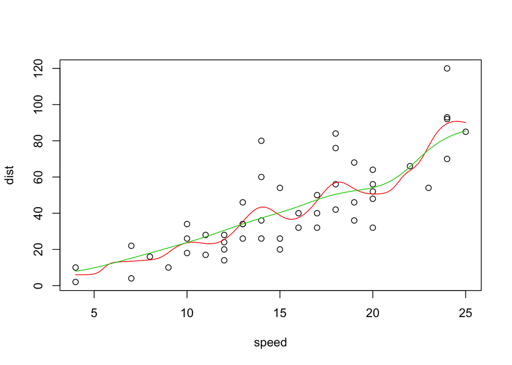

```r
with(cars, {
    plot(speed, dist)
    lines(ksmooth(speed, dist, "normal", bandwidth = 2), col = 2)
    lines(ksmooth(speed, dist, "normal", bandwidth = 5), col = 3)
})
```

GAMs.

The `caret` package may be helpful to avoid learning various syntax here, but be careful to understand what `caret` is assuming.

See [this blog post](https://www.r-bloggers.com/modelling-seasonal-data-with-gams/) for a more detailed info on various features and understanding what’s under the hood.

```r
library(gam)
data(kyphosis)
gam.object <- gam(Kyphosis ~ s(Age,4) + Number, family = binomial, data=kyphosis,
    trace=TRUE)
```

```
## GAM s.wam loop 1: deviance = 66.42095
## GAM s.wam loop 2: deviance = 63.77252
## GAM s.wam loop 3: deviance = 63.25199
## GAM s.wam loop 4: deviance = 63.13399
## GAM s.wam loop 5: deviance = 63.11016
## GAM s.wam loop 6: deviance = 63.10748
## GAM s.wam loop 7: deviance = 63.10727
## GAM s.wam loop 8: deviance = 63.10725
## GAM s.wam loop 9: deviance = 63.10725
```

```r
summary(gam.object)
```

```
##
## Call: gam(formula = Kyphosis ~ s(Age, 4) + Number, family = binomial,
##     data = kyphosis, trace = TRUE)
## Deviance Residuals:
##     Min      1Q  Median      3Q     Max
## -1.7844 -0.7190 -0.3593 -0.1199  2.3198
##
## (Dispersion Parameter for binomial family taken to be 1)
##
##     Null Deviance: 83.2345 on 80 degrees of freedom
## Residual Deviance: 63.1073 on 75 degrees of freedom
## AIC: 75.1072
##
## Number of Local Scoring Iterations: 9
##
## Anova for Parametric Effects
##           Df Sum Sq Mean Sq F value  Pr(>F)
## s(Age, 4)  1  0.382  0.3818  0.4459 0.50632
## Number     1  7.441  7.4412  8.6914 0.00426 **
## Residuals 75 64.212  0.8562
## ---
## Signif. codes:  0 '***' 0.001 '**' 0.01 '*' 0.05 '.' 0.1 ' ' 1
##
## Anova for Nonparametric Effects
##             Npar Df Npar Chisq P(Chi)
## (Intercept)
## s(Age, 4)         3     5.8993 0.1166
## Number
```

```r
gam_pred_values <- predict(gam.object, type = "terms")
head(gam_pred_values, 10)
```

```
##      s(Age, 4)      Number
## 1   0.20433870 -0.58618988
## 2  -0.74761700 -0.58618988
## 3   0.56158423 -0.02758541
## 4  -2.45053879  0.53101907
## 5  -2.50540583 -0.02758541
## 6  -2.50540583 -1.14479435
## 7   0.04912147 -1.14479435
## 8  -0.69122346 -0.58618988
## 9   0.85501883 -1.14479435
## 10  0.01594964  1.08962354
```